# Sports Pay Comparison

Jim Turman

October 24, 2016

## Background

This statistical analysis is done to find if there is a difference in pay between the top 15 salaries in the NFL (National Football League), MLB (Major League Baseball) and the NBA (National Basketball Association). I perform below an ANOVA to test my hypothesis that there is a statistically significant difference between the average pay of the top 15 salaries in each sport.

## Summary Statistics

Below are the summary statistics for the three major sports in the United States, the NFL, NBA and MLB.

```
## $mlb
##                  sum                 mean               median
##              "400.6"   "26.7066666666667"                 "25"
##                 mode                  var                   sd
##            "numeric"   "13.6678095238095"   "3.69700007084251"
##                    n             kurtosis                 skew
##                 "15" "-0.378451593384341"  "0.922506092204073"
##                  max                  min                range
##               "34.5"               "22.7"               "11.8"
##         quartiles.0%        quartiles.25%        quartiles.50%
##               "22.7"               "24.5"                 "25"
##        quartiles.75%       quartiles.100%                  iqr
##                 "28"               "34.5"                "3.5"
##
## $nba
##                 sum                mean              median
##             "356.5"  "23.7666666666667"              "23.2"
##                mode                 var                  sd
##           "numeric"  "6.93095238095238"   "2.6326701998071"
##                   n            kurtosis                skew
##                "15" "0.957128923277273"  "1.25151000102872"
##                 max                 min               range
##              "30.9"              "21.2"               "9.7"
##        quartiles.0%       quartiles.25%       quartiles.50%
##              "21.2"              "22.1"              "23.2"
##       quartiles.75%      quartiles.100%                 iqr
##              "24.8"              "30.9"               "2.7"
##
## $nfl
##                sum               mean             median
##            "390.6"            "26.04"             "23.3"
##               mode                var                 sd
##          "numeric" "65.1182857142857" "8.06959018254866"
##                  n           kurtosis               skew
##               "15" "1.80289829518881" "1.61468849924971"
##                max                min              range
##             "48.9"             "19.1"             "29.8"
##       quartiles.0%      quartiles.25%      quartiles.50%
##             "19.1"             "21.7"             "23.3"
##      quartiles.75%     quartiles.100%                iqr
##            "27.45"             "48.9"             "5.75"
```

## Shapiro-Wilk Test

```
##
##  Shapiro-Wilk normality test
##
## data:  tot
## W = 0.79041, p-value = 1.474e-06
```

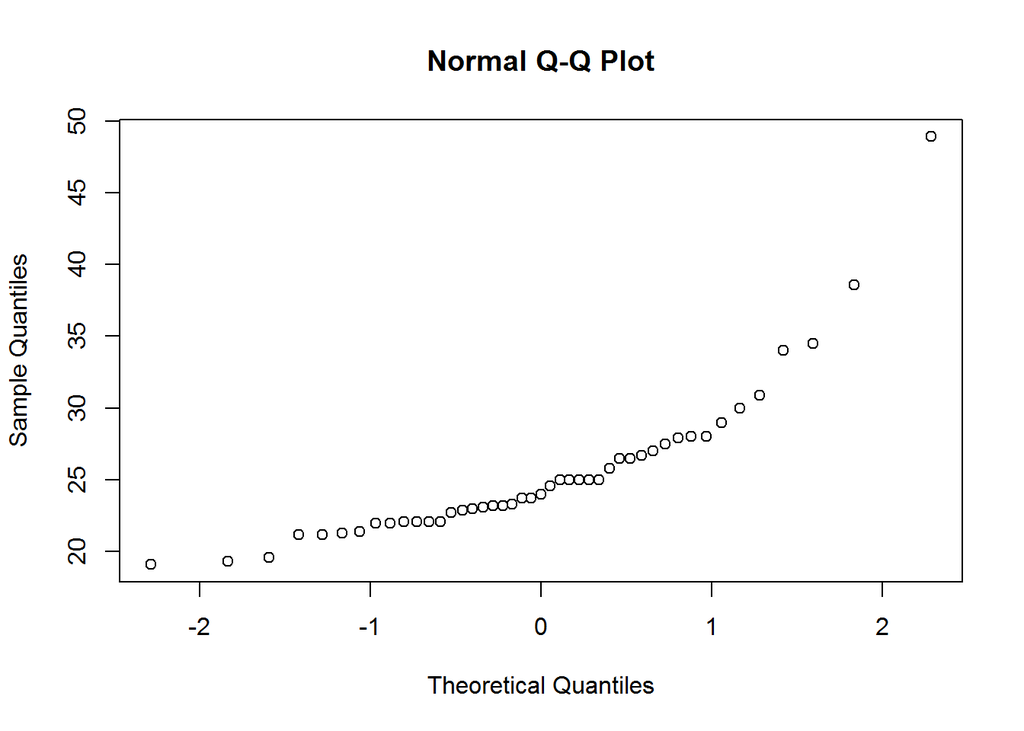

## Anova Hypothesis Test

This test is to decide whether or not there is a statistically significant difference between the average of the top 15 salaries of the three sports leagues. For this test I again use the standard .05 level of significance to determing whether or not to reject the null hypothesis that there is no significant difference between the average top 15 salary’s of the different leagues. Because my P value is .298 > .05 the data does not suggest that there is a statistically signifcant difference between the average top salary based on league.

```
##             Df Sum Sq Mean Sq F value Pr(>F)
## group        2   71.3   35.64   1.247  0.298
## Residuals   42 1200.0   28.57
```

## Tukey Post Hoc Test

This test is to determine which means may have a difference between each other. The left hand column shows the two leagues that are being compared and the right hand shows the p value. The lower the P value the more significant the difference between the means of the leagues. I use a significance value of .05 to determine if the difference is statistically significant. This test shows that the least difference between averages is NFL to MLB and the largest difference is between NBA and MLB. Though this is interesting the P values are still greater than .05 so I cannot say that there is a statistically significant difference between the average top 15 salaries of these leagues.

```
##   Tukey multiple comparisons of means
##     95% family-wise confidence level
##
## Fit: aov(formula = fit)
##
## $group
##               diff       lwr      upr     p adj
## nba-mlb -2.9400000 -7.681963 1.801963 0.2983102
## nfl-mlb -0.6666667 -5.408629 4.075296 0.9378129
## nfl-nba  2.2733333 -2.468629 7.015296 0.4805387
```

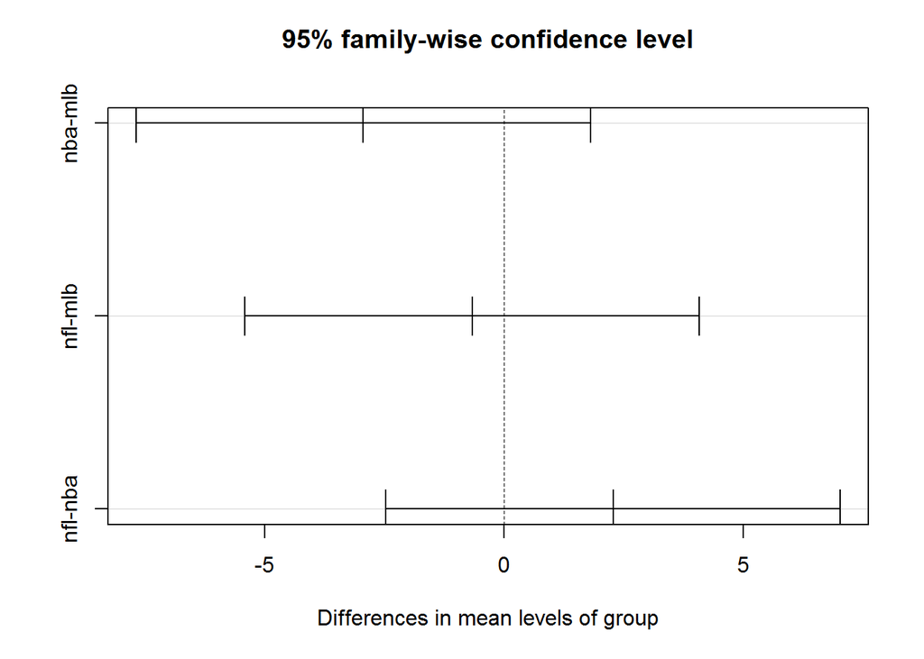

## Levene’s Test

This test is used to determine the homogeneity of variance for the three leagues. I use an alpha value of .05 to determing the level of significance. If P is less than .05 then I can conclude that I am 95% certain that the variance between the leagues salaries is significantly different. The P value for the group is .1229 > .05 so I cannot say that there is a statistically significant difference in variance between the leagues.

```
## Levene's Test for Homogeneity of Variance (center = median)
##       Df F value Pr(>F)
## group  2   2.205 0.1229
##       42
```

## Conclusion

Through the findings of the tests above I can conclude that there is no statistically significant difference between the average salaries of the top 15 players in each league. What this really means is that the top 15 salaries of the NFL, NBA and MLB are very similar to each other. If people are going to chose between sports to play professionally simply based on pay, there is no real difference for the highest paid athletes. To find the difference for the average pay of athletes in each league the sample sizes could be expanded for each league, because of the difficulty of obtaining that data I stuck with the top 15 salaries.